# Supplementary File

APB

1/8/2021

**Supplmental Figure 1.** 250 taxa helminth molecular phylogeny

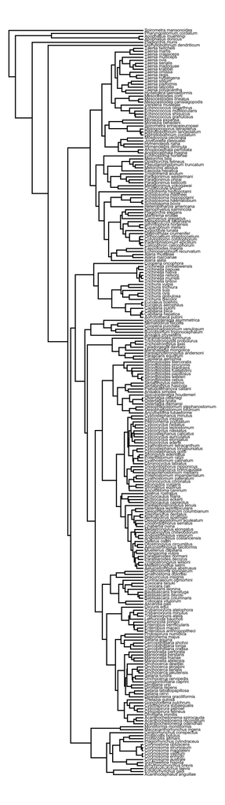

**Supplemental Figure 2.** The likelihood ratio distributions for BM versus OU(3).

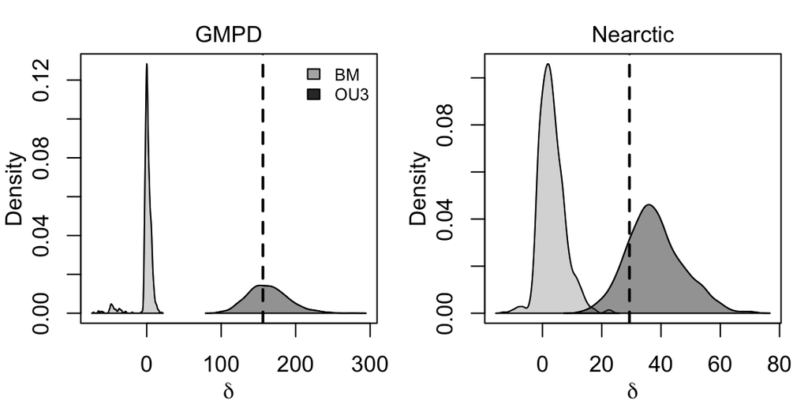

**Supplemental Figure 3.** The likelihood ratio distributions for OU(1) versus OU(3).

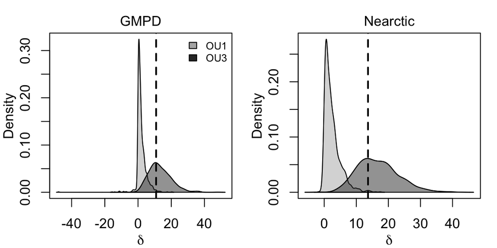

**Supplemental Table 1.** Summary table for evolutionary models of MPD in the Nearctic dataset

```
## # A tibble: 3 × 4
##   model  aicc deltaaicc     waicc
##   <chr> <dbl>     <dbl>     <dbl>
## 1 OU3    987.      0    0.990
## 2 OU1    996.      9.22 0.00985
## 3 BM    1010.     22.8  0.0000112
```

**Supplemental Table 2.** Summary table for evolutionary models of MPD in the GMPD

```
## # A tibble: 3 × 4
##   model  aicc deltaaicc    waicc
##   <chr> <dbl>     <dbl>    <dbl>
## 1 OU3   2416.      0    9.67e- 1
## 2 OU1   2422.      6.74 3.32e- 2
## 3 BM    2565.    150.   2.87e-33
```

Mammal phylogeny colored by the parasite range of each host for the Nearctic dataset (mammals infected by a single helminth have a value of 0)

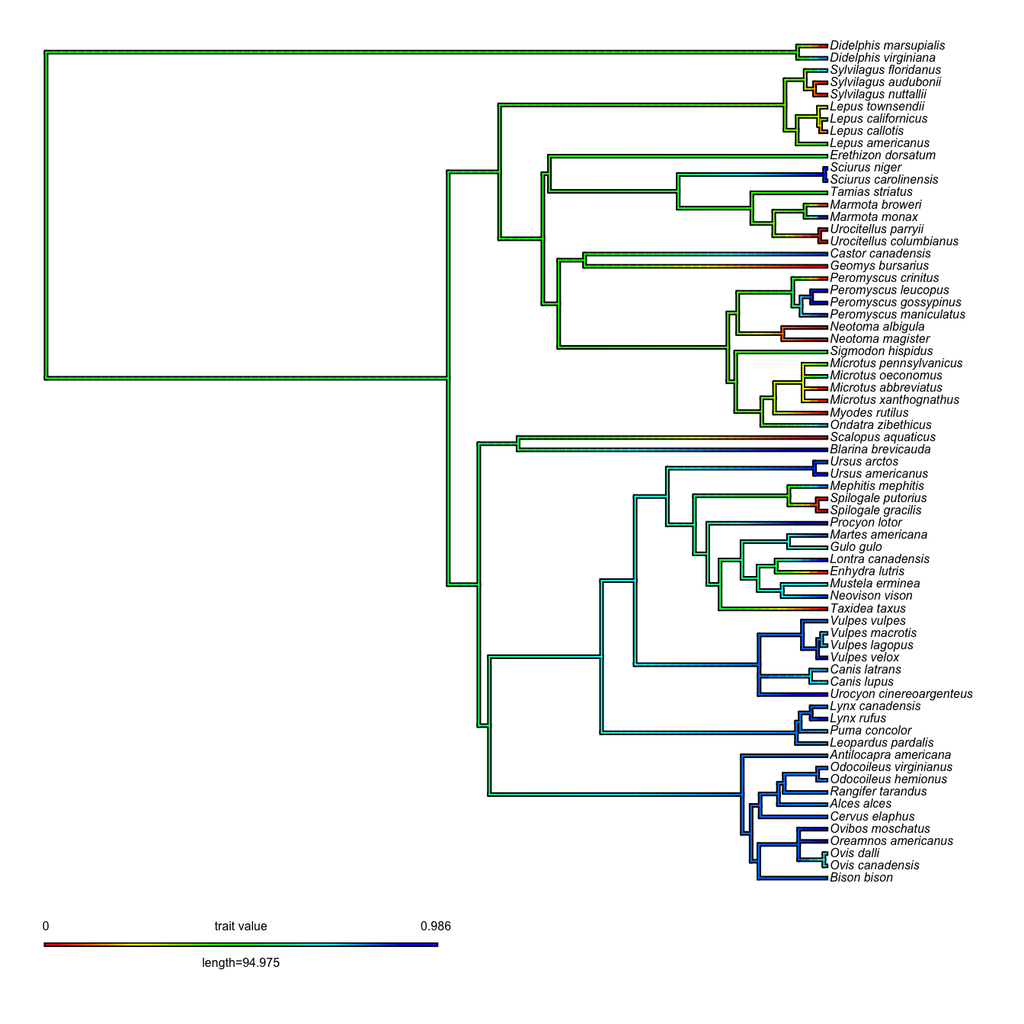

Mammal phylogeny colored by the parasite range of each host for the GMPD (mammals infected by a single helminth have a value of 0)

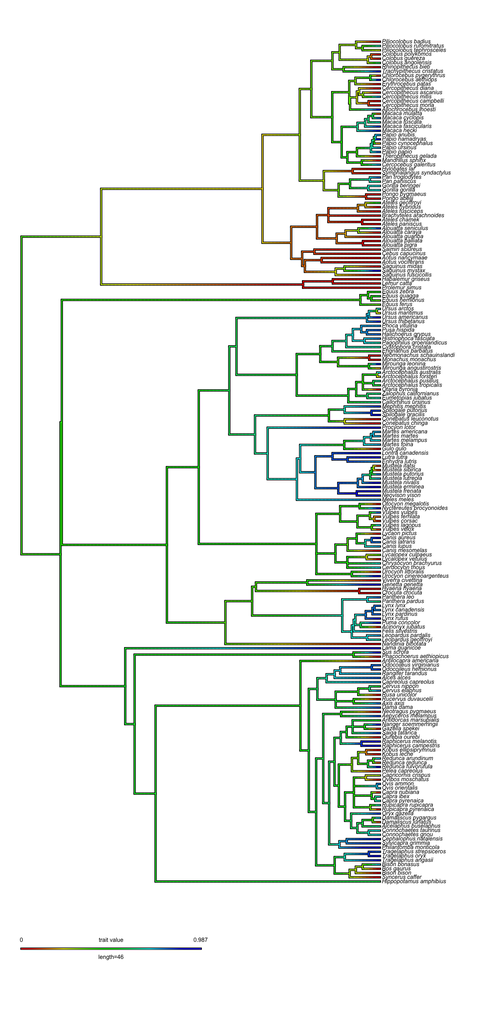

**Supplemental Figure 4.** Mean pairwise phylogenetic distance (MPD) of helminths infecting each mammal compared to their phylogenetic distance to humans in the GMPD and Nearctic dataset. *Didelphis virginiana* and *Didelphis marsupialis* are most distantly related to humans (PD = 380), thus were excluded from the figure.

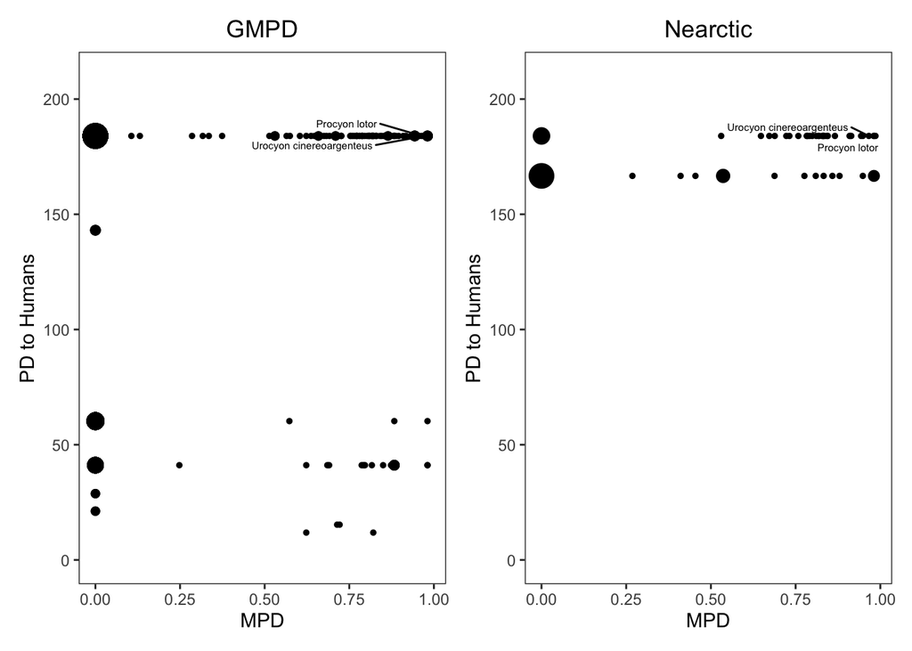